# PS7 Synthetic Controls

Philipp Ketz & Frederik Stroessenreuther

2026

We revisit the case study of Abadie, Diamond, and Hainmueller (2015) on the effect of German reunification on GDP per capita. The data is `repgermany.dta`.

```r
rm(list = ls())
library(foreign)
library(Synth)
library(xtable)

d <- read.dta("repgermany.dta")
```

# 1 Prepare the data

*Predictors: `gdp`, `trade`, `infrate`, `industry` averaged 1981–1990; `schooling` averaged over 1980 and 1985; `invest80` in 1980. Minimise MSPE over 1960–1990. Plot window: 1960–2003.*

```r
dataprep.out <- dataprep(
  foo            = d,
  predictors     = c("gdp", "trade", "infrate", "industry"),
  dependent      = "gdp",
  unit.variable  = 1,
  time.variable  = 3,
  special.predictors = list(
    list("schooling", c(1980, 1985), c("mean")),
    list("invest80",  1980,          c("mean"))
  ),
  treatment.identifier = 7,
  controls.identifier  = unique(d$index)[-7],
  time.predictors.prior = 1981:1990,
  time.optimize.ssr     = 1960:1990,
  unit.names.variable   = 2,
  time.plot             = 1960:2003
)
```

```
#>
#>  Missing data- treated unit; predictor: industry ; for period: 1990
#>  We ignore (na.rm = TRUE) all missing values for predictors.op.
```

# 2 Synthetic control with default settings

*Obtain weights using `synth` with default values for `ipop`. Comment on the weights W.*

```r
synth.out <- synth(
  data.prep.obj = dataprep.out
)
```

```
#>
#> X1, X0, Z1, Z0 all come directly from dataprep object.
#>
#>
#> ****************
#>  searching for synthetic control unit
#>
#>
#> ****************
#> ****************
#> ****************
#>
#> MSPE (LOSS V): 7877.968
#>
#> solution.v:
#>  0.9659369 0.007790493 1.30328e-05 0.0003393711 0.016031 0.009889173
#>
#> solution.w:
#>  0.1980299 0.008880372 0.4423182 0.006960169 0.009180423 0.01136716 0.01030038 0.008808892 0.01581079 0.1510228 0.06500755 0.009145877 0.008203943 0.008726466 0.03084278 0.01539423
```

```r
synth.tables <- synth.tab(
  dataprep.res = dataprep.out,
  synth.res    = synth.out
)
synth.tables
```

```
#> $tab.pred
#>                               Treated Synthetic Sample Mean
#> gdp                         15808.900 15808.897   13669.381
#> trade                          56.778    57.460      59.831
#> infrate                         2.595     4.425       7.617
#> industry                       34.538    33.971      33.794
#> special.schooling.1980.1985    55.500    54.938      38.659
#> special.invest80.1980          27.018    26.915      25.895
#>
#> $tab.v
#>                             v.weights
#> gdp                         0.966
#> trade                       0.008
#> infrate                     0
#> industry                    0
#> special.schooling.1980.1985 0.016
#> special.invest80.1980       0.01
#>
#> $tab.w
#>    w.weights  unit.names unit.numbers
#> 1      0.198         USA            1
#> 2      0.009          UK            2
#> 3      0.442     Austria            3
#> 4      0.007     Belgium            4
#> 5      0.009     Denmark            5
#> 6      0.011      France            6
#> 8      0.010       Italy            8
#> 9      0.009 Netherlands            9
#> 10     0.016      Norway           10
#> 12     0.151 Switzerland           12
#> 14     0.065       Japan           14
#> 16     0.009      Greece           16
#> 18     0.008    Portugal           18
#> 19     0.009       Spain           19
#> 20     0.031   Australia           20
#> 21     0.015 New Zealand           21
#>
#> $tab.loss
#>            Loss W   Loss V
#> [1,] 4.590596e-05 7877.968
```

**Answer:** The default values of `synth` don’t work well — they produce too many non-zero weights. The solution is not sparse, which is undesirable for interpretability.

# 3 Synthetic control with refined optimizer settings

*Use `Margin.ipop=.0005, Sigf.ipop=10, Bound.ipop=10`. Plot the path plot with a vertical line at 1990.*

```r
synth.out <- synth(
  data.prep.obj = dataprep.out,
  Margin.ipop = .0005, Sigf.ipop = 10, Bound.ipop = 10
)
```

```
#>
#> X1, X0, Z1, Z0 all come directly from dataprep object.
#>
#>
#> ****************
#>  searching for synthetic control unit
#>
#>
#> ****************
#> ****************
#> ****************
#>
#> MSPE (LOSS V): 10241.75
#>
#> solution.v:
#>  0.6394482 1.73308e-05 0.001279071 0.00347564 0.04953715 0.3062426
#>
#> solution.w:
#>  0.1353166 0.01668644 0.4792926 1.2e-09 5e-10 5e-10 4e-10 0.09912601 4e-10 0.1660957 0.1034826 2e-10 2e-10 4e-10 3e-10 3e-10
```

```r
synth.tables <- synth.tab(
  dataprep.res = dataprep.out,
  synth.res    = synth.out
)
synth.tables
```

```
#> $tab.pred
#>                               Treated Synthetic Sample Mean
#> gdp                         15808.900 15808.368   13669.381
#> trade                          56.778    64.011      59.831
#> infrate                         2.595     3.474       7.617
#> industry                       34.538    34.435      33.794
#> special.schooling.1980.1985    55.500    55.495      38.659
#> special.invest80.1980          27.018    27.019      25.895
#>
#> $tab.v
#>                             v.weights
#> gdp                         0.639
#> trade                       0
#> infrate                     0.001
#> industry                    0.003
#> special.schooling.1980.1985 0.05
#> special.invest80.1980       0.306
#>
#> $tab.w
#>    w.weights  unit.names unit.numbers
#> 1      0.135         USA            1
#> 2      0.017          UK            2
#> 3      0.479     Austria            3
#> 4      0.000     Belgium            4
#> 5      0.000     Denmark            5
#> 6      0.000      France            6
#> 8      0.000       Italy            8
#> 9      0.099 Netherlands            9
#> 10     0.000      Norway           10
#> 12     0.166 Switzerland           12
#> 14     0.103       Japan           14
#> 16     0.000      Greece           16
#> 18     0.000    Portugal           18
#> 19     0.000       Spain           19
#> 20     0.000   Australia           20
#> 21     0.000 New Zealand           21
#>
#> $tab.loss
#>            Loss W   Loss V
#> [1,] 4.599109e-05 10241.75
```

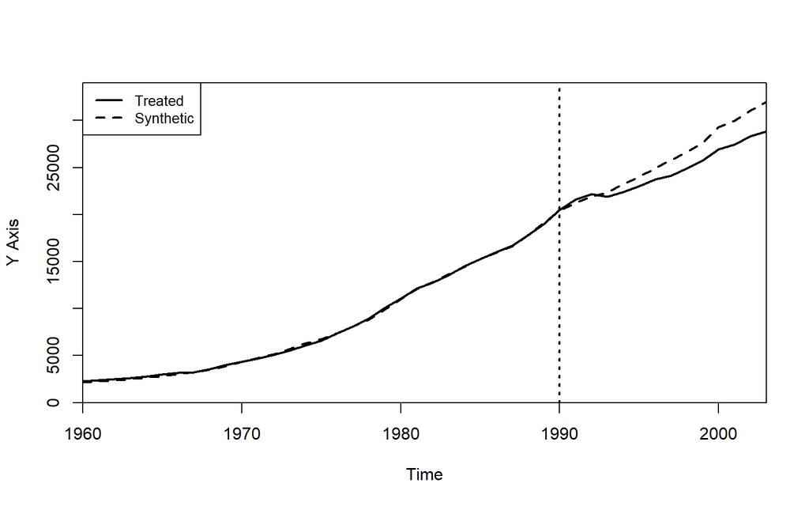

Synthetic control path plot (c)

```r
path.plot(
  synth.res        = synth.out,
  dataprep.res     = dataprep.out,
  Ylim             = c(0, 34000),
  tr.intake        = 1990,
  Legend.position  = "topleft"
)
```

# 4 Uniform weights for V

*Redo (c) with uniform weights for V. How do findings compare to (c)?*

```r
synth.out <- synth(
  data.prep.obj = dataprep.out,
  custom.v      = rep(1, 6) / 6
)
```

```
#>
#> X1, X0, Z1, Z0 all come directly from dataprep object.
#>
#>
#> ****************
#>  optimization over w weights: computing synthtic control unit
#>
#>
#>
#> ****************
#>  v weights supplied manually: computing synthtic control unit
#>
#>
#>
#> ****************
#> ****************
#> ****************
#>
#> MSPE (LOSS V): 20993.69
#>
#> solution.v:
#>  0.1666667 0.1666667 0.1666667 0.1666667 0.1666667 0.1666667
#>
#> solution.w:
#>  0.2122905 2.73e-06 0.4223734 4.1778e-06 7.2914e-06 4.0714e-06 1.8276e-06 0.09739176 1.1704e-06 0.1016068 0.1663073 1.2619e-06 1.0816e-06 2.2563e-06 2.1529e-06 2.1141e-06
```

```r
synth.tables <- synth.tab(
  dataprep.res = dataprep.out,
  synth.res    = synth.out
)
synth.tables
```

```
#> $tab.pred
#>                               Treated Synthetic Sample Mean
#> gdp                         15808.900 15734.921   13669.381
#> trade                          56.778    57.024      59.831
#> infrate                         2.595     3.433       7.617
#> industry                       34.538    34.493      33.794
#> special.schooling.1980.1985    55.500    55.101      38.659
#> special.invest80.1980          27.018    27.095      25.895
#>
#> $tab.v
#>                             v.weights
#> gdp                             0.167
#> trade                           0.167
#> infrate                         0.167
#> industry                        0.167
#> special.schooling.1980.1985     0.167
#> special.invest80.1980           0.167
#>
#> $tab.w
#>    w.weights  unit.names unit.numbers
#> 1      0.212         USA            1
#> 2      0.000          UK            2
#> 3      0.422     Austria            3
#> 4      0.000     Belgium            4
#> 5      0.000     Denmark            5
#> 6      0.000      France            6
#> 8      0.000       Italy            8
#> 9      0.097 Netherlands            9
#> 10     0.000      Norway           10
#> 12     0.102 Switzerland           12
#> 14     0.166       Japan           14
#> 16     0.000      Greece           16
#> 18     0.000    Portugal           18
#> 19     0.000       Spain           19
#> 20     0.000   Australia           20
#> 21     0.000 New Zealand           21
#>
#> $tab.loss
#>           Loss W   Loss V
#> [1,] 0.005266528 20993.69
```

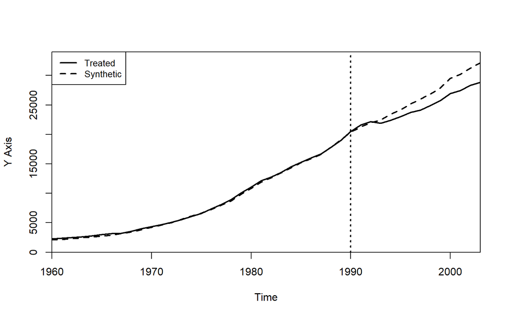

Synthetic control path plot (d) — uniform V

```r
path.plot(
  synth.res       = synth.out,
  dataprep.res    = dataprep.out,
  Ylim            = c(0, 34000),
  tr.intake       = 1990,
  Legend.position = "topleft"
)
```

**Answer:** The results are pretty similar to (c). The weights W are slightly different, but the graph is close enough. This is good news — the choice of V should not matter too much.

# 5 Regression weights

*Construct the regression weights proposed by Abadie (including a vector of constants). Compare to (c) and (d).*

```r
X0 <- cbind(1, t(dataprep.out$X0))
X1 <- as.matrix(c(1, dataprep.out$X1))
W  <- X0 %*% solve(t(X0) %*% X0) %*% X1

synth.out.reg           <- synth.out
synth.out.reg$solution.w <- W

synth.tables <- synth.tab(
  dataprep.res = dataprep.out,
  synth.res    = synth.out.reg
)
synth.tables
```

```
#> $tab.pred
#>                               Treated Synthetic Sample Mean
#> gdp                         15808.900 15808.900   13669.381
#> trade                          56.778    56.778      59.831
#> infrate                         2.595     2.595       7.617
#> industry                       34.538    34.538      33.794
#> special.schooling.1980.1985    55.500    55.500      38.659
#> special.invest80.1980          27.018    27.018      25.895
#>
#> $tab.v
#>                             v.weights
#> gdp                             0.167
#> trade                           0.167
#> infrate                         0.167
#> industry                        0.167
#> special.schooling.1980.1985     0.167
#> special.invest80.1980           0.167
#>
#> $tab.w
#>    w.weights  unit.names unit.numbers
#> 1      0.131         USA            1
#> 2      0.062          UK            2
#> 3      0.259     Austria            3
#> 4     -0.003     Belgium            4
#> 5      0.079     Denmark            5
#> 6      0.042      France            6
#> 8     -0.048       Italy            8
#> 9      0.137 Netherlands            9
#> 10     0.043      Norway           10
#> 12     0.045 Switzerland           12
#> 14     0.187       Japan           14
#> 16    -0.086      Greece           16
#> 18    -0.081    Portugal           18
#> 19    -0.011       Spain           19
#> 20     0.121   Australia           20
#> 21     0.122 New Zealand           21
#>
#> $tab.loss
#>           Loss W   Loss V
#> [1,] 0.005266528 20993.69
```

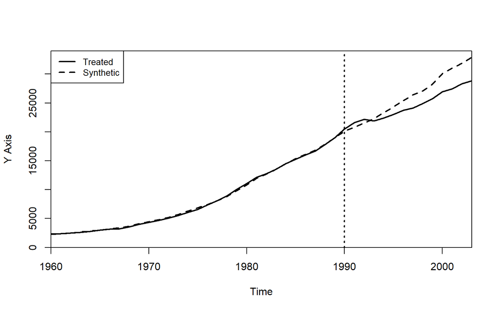

Synthetic control path plot (e) — regression weights

```r
path.plot(
  synth.res       = synth.out.reg,
  dataprep.res    = dataprep.out,
  Ylim            = c(0, 34000),
  tr.intake       = 1990,
  Legend.position = "topleft"
)
```

**Answer:** Again, the graph looks similar to above. At least for the data at hand, extrapolation due to the unconstrained regression weights does not seem to be a big deal.

# 6 Single predictor: GDP 1981–1990

*Use only `gdp` averaged 1981–1990. Describe and interpret findings. How do you interpret the weights W?*

```r
dataprep.out <- dataprep(
  foo           = d,
  predictors    = "gdp",
  dependent     = "gdp",
  unit.variable = 1,
  time.variable = 3,
  treatment.identifier = 7,
  controls.identifier  = unique(d$index)[-7],
  time.predictors.prior = 1981:1990,
  time.optimize.ssr     = 1960:1990,
  unit.names.variable   = 2,
  time.plot             = 1960:2003
)
```

```r
synth.out <- synth(
  data.prep.obj = dataprep.out,
  custom.v      = 1
)
```

```
#>
#> X1, X0, Z1, Z0 all come directly from dataprep object.
#>
#>
#> ****************
#>  optimization over w weights: computing synthtic control unit
#>
#>
#>
#> ****************
#> ****************
#> ****************
#>
#> MSPE (LOSS V): 80506.55
#>
#> solution.v:
#>  1
#>
#> solution.w:
#>  0.05174178 0.03919491 0.04322369 0.04230958 0.04330301 0.04220589 0.04140393 0.04253102 0.04235356 0.3905415 0.04111451 0.03359801 0.03079034 0.03444086 0.04234953 0.03889785
```

```r
synth.tables <- synth.tab(
  dataprep.res = dataprep.out,
  synth.res    = synth.out
)
synth.tables
```

```
#> $tab.pred
#>     Treated Synthetic Sample Mean
#> gdp 15808.9   15808.9    13669.38
#>
#> $tab.v
#>     v.weights
#> gdp         1
#>
#> $tab.w
#>    w.weights  unit.names unit.numbers
#> 1      0.052         USA            1
#> 2      0.039          UK            2
#> 3      0.043     Austria            3
#> 4      0.042     Belgium            4
#> 5      0.043     Denmark            5
#> 6      0.042      France            6
#> 8      0.041       Italy            8
#> 9      0.043 Netherlands            9
#> 10     0.042      Norway           10
#> 12     0.391 Switzerland           12
#> 14     0.041       Japan           14
#> 16     0.034      Greece           16
#> 18     0.031    Portugal           18
#> 19     0.034       Spain           19
#> 20     0.042   Australia           20
#> 21     0.039 New Zealand           21
#>
#> $tab.loss
#>            Loss W   Loss V
#> [1,] 1.638466e-13 80506.55
```

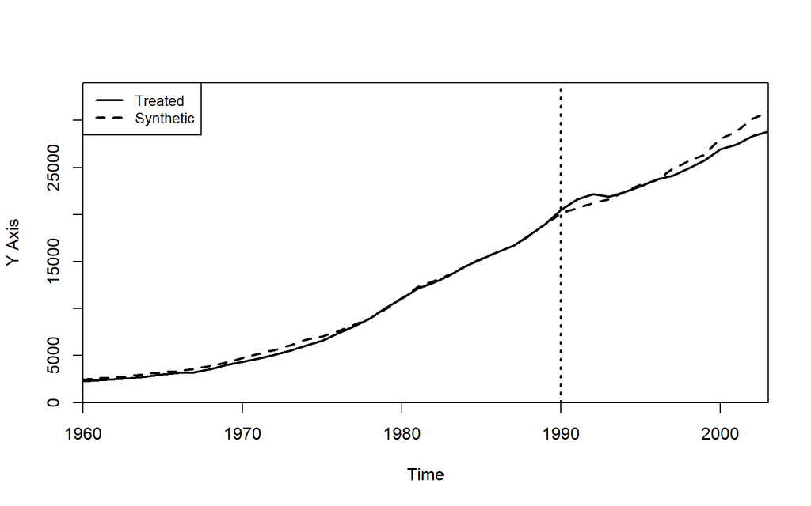

Synthetic control path plot (f) — single predictor

```r
path.plot(
  synth.res       = synth.out,
  dataprep.res    = dataprep.out,
  Ylim            = c(0, 34000),
  tr.intake       = 1990,
  Legend.position = "topleft"
)
```

**Answer:**

- The weights are not sparse. This is because we are able to get a perfect fit of the predictors — in that case there are infinitely many weights that give a perfect fit, and it is unclear how the `synth` function picks among them.
- We see that the pre-treatment fit is not perfect, particularly between 1971 and 1980.

# 7 Two GDP predictors

*Add `gdp` averaged 1971–1980 as a second predictor (uniform V). Interpret in comparison to (f).*

```r
dataprep.out <- dataprep(
  foo           = d,
  predictors    = "gdp",
  dependent     = "gdp",
  unit.variable = 1,
  time.variable = 3,
  special.predictors = list(
    list("gdp", 1971:1980, c("mean"))
  ),
  treatment.identifier = 7,
  controls.identifier  = unique(d$index)[-7],
  time.predictors.prior = 1981:1990,
  time.optimize.ssr     = 1960:1990,
  unit.names.variable   = 2,
  time.plot             = 1960:2003
)
```

```r
synth.out <- synth(
  data.prep.obj = dataprep.out,
  custom.v      = c(0.5, 0.5)
)
```

```
#>
#> X1, X0, Z1, Z0 all come directly from dataprep object.
#>
#>
#> ****************
#>  optimization over w weights: computing synthtic control unit
#>
#>
#>
#> ****************
#>  v weights supplied manually: computing synthtic control unit
#>
#>
#>
#> ****************
#> ****************
#> ****************
#>
#> MSPE (LOSS V): 17580.89
#>
#> solution.v:
#>  0.5 0.5
#>
#> solution.w:
#>  0.3507108 0.02915629 0.03873213 0.03323469 0.02865323 0.03379223 0.03694439 0.02608989 0.1294785 0.127859 0.0463703 0.02124725 0.02303421 0.02398545 0.02769355 0.02301811
```

```r
synth.tables <- synth.tab(
  dataprep.res = dataprep.out,
  synth.res    = synth.out
)
synth.tables
```

```
#> $tab.pred
#>                       Treated Synthetic Sample Mean
#> gdp                   15808.9 15806.935   13669.381
#> special.gdp.1971.1980  7350.6  7351.336    6445.663
#>
#> $tab.v
#>                       v.weights
#> gdp                         0.5
#> special.gdp.1971.1980       0.5
#>
#> $tab.w
#>    w.weights  unit.names unit.numbers
#> 1      0.351         USA            1
#> 2      0.029          UK            2
#> 3      0.039     Austria            3
#> 4      0.033     Belgium            4
#> 5      0.029     Denmark            5
#> 6      0.034      France            6
#> 8      0.037       Italy            8
#> 9      0.026 Netherlands            9
#> 10     0.129      Norway           10
#> 12     0.128 Switzerland           12
#> 14     0.046       Japan           14
#> 16     0.021      Greece           16
#> 18     0.023    Portugal           18
#> 19     0.024       Spain           19
#> 20     0.028   Australia           20
#> 21     0.023 New Zealand           21
#>
#> $tab.loss
#>            Loss W   Loss V
#> [1,] 3.781931e-07 17580.89
```

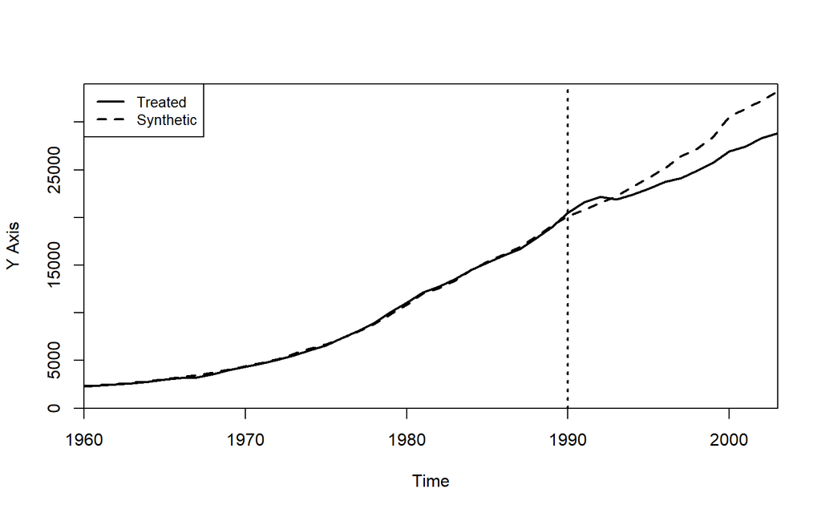

Synthetic control path plot (g) — two GDP predictors

```r
path.plot(
  synth.res       = synth.out,
  dataprep.res    = dataprep.out,
  Ylim            = c(0, 34000),
  tr.intake       = 1990,
  Legend.position = "topleft"
)
```

**Answer:**

- Simply adding the earlier GDP period as a predictor fixes the pre-treatment fit. The graph looks similar to above and here it seems no other predictors are needed for a good fit.
- The weights are not sparse as in (f) — the story is the same: while the fit of the predictors is not perfect, the difference is due to numerical error. To see this, note that “Loss W” is still zero.

# 8 Placebo in time: predictors from 1971–1980

*Redo (c) using predictors averaged 1971–1980, minimising MSPE over 1960–1980. Include a vertical line at 1980. How do you interpret the findings?*

```r
dataprep.out <- dataprep(
  foo           = d,
  predictors    = c("gdp", "trade", "infrate", "industry"),
  dependent     = "gdp",
  unit.variable = 1,
  time.variable = 3,
  special.predictors = list(
    list("schooling", c(1970, 1975), c("mean")),
    list("invest80",  1980,          c("mean"))
  ),
  treatment.identifier = 7,
  controls.identifier  = unique(d$index)[-7],
  time.predictors.prior = 1971:1980,
  time.optimize.ssr     = 1960:1980,
  unit.names.variable   = 2,
  time.plot             = 1960:2003
)
```

```r
synth.out <- synth(
  data.prep.obj = dataprep.out
)
```

```
#>
#> X1, X0, Z1, Z0 all come directly from dataprep object.
#>
#>
#> ****************
#>  searching for synthetic control unit
#>
#>
#> ****************
#> ****************
#> ****************
#>
#> MSPE (LOSS V): 5484.237
#>
#> solution.v:
#>  0.4127656 0.5690131 0.004642786 3.809e-07 0.009465204 0.004113001
#>
#> solution.w:
#>  0.2831767 1.47e-06 0.5456005 2.8311e-06 2.3781e-06 3.9065e-06 2.8204e-06 2.8916e-06 5.861e-06 0.04041194 1.8289e-06 1.8835e-06 1.71e-06 1.9316e-06 0.1307814 0
```

```r
synth.tables <- synth.tab(
  dataprep.res = dataprep.out,
  synth.res    = synth.out
)
synth.tables
```

```
#> $tab.pred
#>                              Treated Synthetic Sample Mean
#> gdp                         7350.600  7349.827    6445.663
#> trade                         46.214    46.269      52.806
#> infrate                        4.958     7.231      10.623
#> industry                      43.943    37.689      36.935
#> special.schooling.1970.1975   51.900    45.179      32.456
#> special.invest80.1980         27.018    26.008      25.895
#>
#> $tab.v
#>                             v.weights
#> gdp                         0.413
#> trade                       0.569
#> infrate                     0.005
#> industry                    0
#> special.schooling.1970.1975 0.009
#> special.invest80.1980       0.004
#>
#> $tab.w
#>    w.weights  unit.names unit.numbers
#> 1      0.283         USA            1
#> 2      0.000          UK            2
#> 3      0.546     Austria            3
#> 4      0.000     Belgium            4
#> 5      0.000     Denmark            5
#> 6      0.000      France            6
#> 8      0.000       Italy            8
#> 9      0.000 Netherlands            9
#> 10     0.000      Norway           10
#> 12     0.040 Switzerland           12
#> 14     0.000       Japan           14
#> 16     0.000      Greece           16
#> 18     0.000    Portugal           18
#> 19     0.000       Spain           19
#> 20     0.131   Australia           20
#> 21     0.000 New Zealand           21
#>
#> $tab.loss
#>           Loss W   Loss V
#> [1,] 0.003681218 5484.237
```

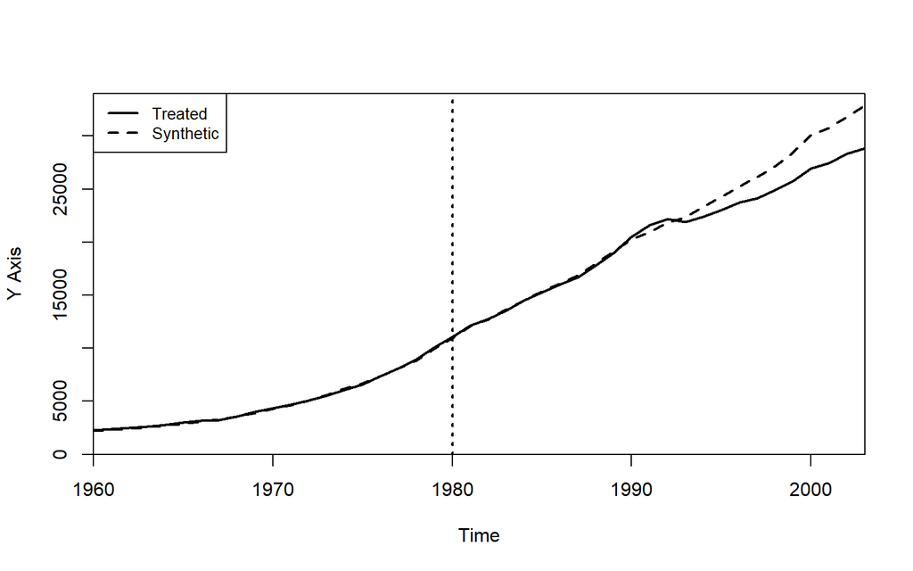

Synthetic control path plot (h) — placebo in time, vertical line at 1980

```r
path.plot(
  synth.res       = synth.out,
  dataprep.res    = dataprep.out,
  Ylim            = c(0, 34000),
  tr.intake       = 1980,
  Legend.position = "topleft"
)
```

**Answer:** This acts as a placebo test. In class, we saw an inference method based on placebos where other countries were assigned treatment. Here, we consider another year. As the graph doesn’t change much, this “confirms” the initial estimate — the synthetic control tracks Germany well before 1980, and the post-1990 gap remains visible.

# 9 Placebo in time with uniform V

*Redo (h) using uniform weights for V. What do you conclude with respect to the choice of V?*

```r
synth.out <- synth(
  data.prep.obj = dataprep.out,
  custom.v      = rep(1, 6) / 6
)
```

```
#>
#> X1, X0, Z1, Z0 all come directly from dataprep object.
#>
#>
#> ****************
#>  optimization over w weights: computing synthtic control unit
#>
#>
#>
#> ****************
#>  v weights supplied manually: computing synthtic control unit
#>
#>
#>
#> ****************
#> ****************
#> ****************
#>
#> MSPE (LOSS V): 462853.6
#>
#> solution.v:
#>  0.1666667 0.1666667 0.1666667 0.1666667 0.1666667 0.1666667
#>
#> solution.w:
#>  0.02265574 0.0002276821 0.8406814 1.03e-08 1.69522e-05 4.27622e-05 4.33986e-05 4.0237e-06 1.0736e-06 2.62623e-05 0.1361194 1.43058e-05 4.1231e-06 2.77064e-05 0.0001175922 1.7614e-05
```

```r
synth.tables <- synth.tab(
  dataprep.res = dataprep.out,
  synth.res    = synth.out
)
synth.tables
```

```
#> $tab.pred
#>                              Treated Synthetic Sample Mean
#> gdp                         7350.600  6657.324    6445.663
#> trade                         46.214    57.653      52.806
#> infrate                        4.958     6.717      10.623
#> industry                      43.943    40.307      36.935
#> special.schooling.1970.1975   51.900    44.556      32.456
#> special.invest80.1980         27.018    27.679      25.895
#>
#> $tab.v
#>                             v.weights
#> gdp                             0.167
#> trade                           0.167
#> infrate                         0.167
#> industry                        0.167
#> special.schooling.1970.1975     0.167
#> special.invest80.1980           0.167
#>
#> $tab.w
#>    w.weights  unit.names unit.numbers
#> 1      0.023         USA            1
#> 2      0.000          UK            2
#> 3      0.841     Austria            3
#> 4      0.000     Belgium            4
#> 5      0.000     Denmark            5
#> 6      0.000      France            6
#> 8      0.000       Italy            8
#> 9      0.000 Netherlands            9
#> 10     0.000      Norway           10
#> 12     0.000 Switzerland           12
#> 14     0.136       Japan           14
#> 16     0.000      Greece           16
#> 18     0.000    Portugal           18
#> 19     0.000       Spain           19
#> 20     0.000   Australia           20
#> 21     0.000 New Zealand           21
#>
#> $tab.loss
#>         Loss W   Loss V
#> [1,] 0.2903947 462853.6
```

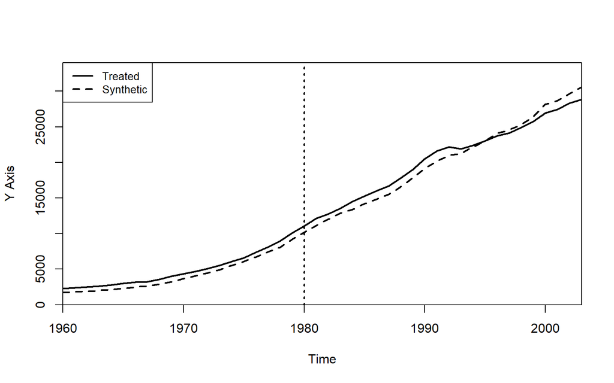

Synthetic control path plot (i) — placebo in time, uniform V

```r
path.plot(
  synth.res       = synth.out,
  dataprep.res    = dataprep.out,
  Ylim            = c(0, 34000),
  tr.intake       = 1980,
  Legend.position = "topleft"
)
```

**Answer:** With uniform weights for V, we are unable to match the level of Germany’s GDP in the pre-treatment period. So, apparently choosing V is important — at least for getting the level right. This contrasts with (c) vs (d) where the choice of V mattered less. The conclusion is that the choice of V can matter, and the optimized V from (c)/(h) should be preferred when it is feasible.